# Introduction

Testing the updated event detection routine that runs only with python. Checking whether consistent with old version.

# Setup

```python
# modules
from pathlib import Path

# import dateutil.relativedelta
# import matplotlib.colors
import matplotlib.pyplot as plt
import numpy as np
import pandas as pd

import hysevt.events.detection
import hysevt.events.metrics
import hysevt.utils.tools

# from matplotlib.gridspec import GridSpec
```

```python
# set base directory
baseDIR = Path("..").resolve()
assert baseDIR.is_dir()

# data directory
dataDIR = "/home/skalevag/Documents/NRC_P8_water_energy_and_sediment/data"
dataDIR = Path(dataDIR)
localDataDIR = baseDIR.joinpath("data")

# station
station_id = 201350  # station id for Vent-Rofental gauging station, as used by HD Tirol
station_name = "vent"
events_version = "automatic_local_minimum_events"

# events directory
eventsDIR = localDataDIR.joinpath("events_database", station_name, events_version)

# results
ODIR = localDataDIR.joinpath("events_database", station_name, "test_hysevt_v0.3")
ODIR.mkdir(exist_ok=True, parents=True)
```

# Data and events

```python
# files
file_data = localDataDIR.joinpath(
    "preprocessed", f"{station_id}_{station_name}_SSC_Q.csv"
)

# data
gauge_data = hysevt.events.metrics.get_gauge_data(file_data)
```

```python
old_events_list = pd.read_csv(
    eventsDIR.joinpath(f"events_list_vent.csv"),
    index_col=0,
)
old_events_list.head()
```

| event_id | start | end |
| --- | --- | --- |
| VEN-AUT-2006-001 | 2006-05-18 08:45:00 | 2006-05-19 09:45:00 |
| VEN-AUT-2006-002 | 2006-05-19 10:00:00 | 2006-05-20 11:45:00 |
| VEN-AUT-2006-003 | 2006-05-28 10:15:00 | 2006-06-05 09:30:00 |
| VEN-AUT-2006-004 | 2006-06-13 09:00:00 | 2006-06-14 08:45:00 |
| VEN-AUT-2006-005 | 2006-06-14 09:00:00 | 2006-06-15 09:30:00 |

# New version detection

```python
help(hysevt.events.detection.hydro_events)
```

```
Help on function hydro_events in module hysevt.events.detection:

hydro_events(qt=None, q=None, t=None, window=21)
    Identify hydrological events with hydrograph separation using local minima method.

    Either pass a streamflow timeseries qt, or streamflow values and datetime values separately.

    Transcribed into python from Anatolii Tsyplenkov's loadflux R package, `hydro_events` function: https://github.com/atsyplenkov/loadflux/blob/beb8266878342ec0757d55b0c2b4b809b6c20940/R/hydro_events.R

    Args:
        qt (pandas.Series, optional): timeseries with streamflow values, must have DatetimeIndex or datetime like index
        q (np.ndarray, optional): streamflow values
        t (np.ndarray, optional): datetime values corresponding to streamflow values
        window (int, optional): window size for local minima search, in hours. Defaults to 21.

    Returns:
        hydro_events: pandas.Series

    References:
    @computer_program{Tsyplenkov2022,
        author = {Anatolii Tsyplenkov},
        doi = {10.5281/ZENODO.6992087},
        month = {8},
        title = {atsyplenkov/loadflux: Zenodo release},
        url = {https://zenodo.org/record/6992087},
        year = {2022},
    }
    @report{Sloto1996,
        author = {Ronald A Sloto and Michèle Y Crouse and Gordon P Eaton},
        doi = {10.3133/wri964040},
        journal = {Water-Resources Investigations Report},
        title = {HYSEP: A Computer Program for Streamflow Hydrograph Separation and Analysis},
        url = {https://pubs.er.usgs.gov/publication/wri964040},
        year = {1996},
    }
```

```python
output_file = ODIR.joinpath("events_list_vent.csv")
```

```python
new_events_list = hysevt.events.detection.hydro_sediment_events(
    path_gauge_data=file_data,
    output_file=output_file,
    event_station_id="VEN",
    keep_removed_events=True,
)
```

# Compare local minima detection between versions

```python
new_events_series = hysevt.events.metrics.get_event_series(new_events_list,gauge_data)
old_events_series = hysevt.events.metrics.get_event_series(old_events_list,gauge_data)
```

The new routine detects the same events like the old one, but the start and end times of the detected events are not the same. It seems like the new is actually a bit better, that the event starts excactly at the local minima. For some reason the old routine seems to detect starts just before the minima.

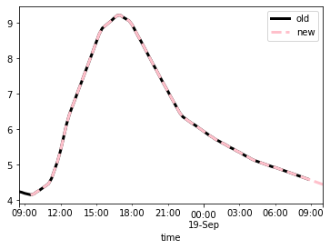

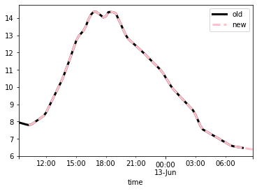

```python
i = 310
old_events_series[i].streamflow.plot(color="k",label="old",linewidth=3)
new_events_series[i].streamflow.plot(color="pink",linestyle="--",label="new",linewidth=3)
plt.legend()

plt.figure()
i = 110
old_events_series[i].streamflow.plot(color="k",label="old",linewidth=3)
new_events_series[i].streamflow.plot(color="pink",linestyle="--",label="new",linewidth=3)
plt.legend()
```

Some events detected by the old routine are not detected by the new one. Below is the same event id, but the detected events are not the same. So the new routine is one event "behind" the old one.

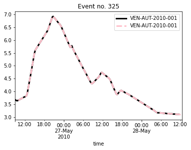

```python
i = 325
old_events_series[i].streamflow.plot(color="k",label=old_events_list.index[i],linewidth=3)
new_events_series[i].streamflow.plot(color="pink",linestyle="--",label=new_events_list.index[i],linewidth=3)
plt.title(f"Event no. {i}")
plt.legend()
```

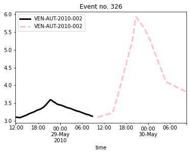

```python
i = 326
old_events_series[i].streamflow.plot(color="k",label=old_events_list.index[i],linewidth=3)
new_events_series[i].streamflow.plot(color="pink",linestyle="--",label=new_events_list.index[i],linewidth=3)
plt.title(f"Event no. {i}")
plt.legend()
```

Then we are back to the same events being detected, but total number wise the new routine has one less events.

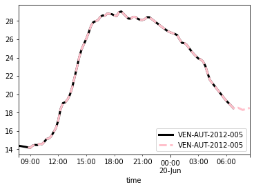

```python
i = 426
old_events_series[i].streamflow.plot(color="k",label=old_events_list.index[i],linewidth=3)
new_events_series[i-1].streamflow.plot(color="pink",linestyle="--",label=new_events_list.index[i-1],linewidth=3)
plt.legend()
```

Then the same thing as before happens, that the new routine misses an event detected by the old one.

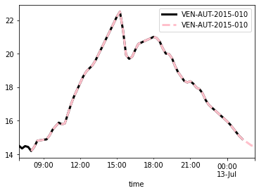

```python
i = 567
old_events_series[i].streamflow.plot(color="k",label=old_events_list.index[i],linewidth=3)
new_events_series[i-1].streamflow.plot(color="pink",linestyle="--",label=new_events_list.index[i-1],linewidth=3)
plt.legend()
```

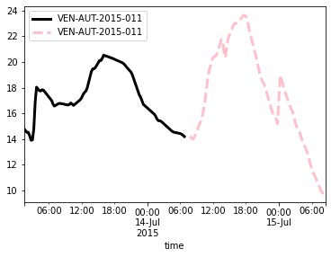

```python
i = 568
old_events_series[i].streamflow.plot(color="k",label=old_events_list.index[i],linewidth=3)
new_events_series[i-1].streamflow.plot(color="pink",linestyle="--",label=new_events_list.index[i-1],linewidth=3)
plt.legend()
```

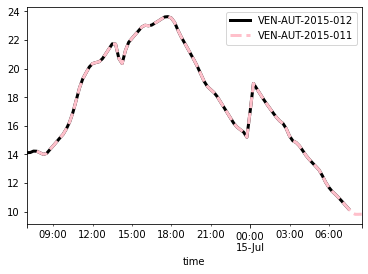

```python
i = 569
old_events_series[i].streamflow.plot(color="k",label=old_events_list.index[i],linewidth=3)
new_events_series[i-2].streamflow.plot(color="pink",linestyle="--",label=new_events_list.index[i-2],linewidth=3)
plt.legend()
```

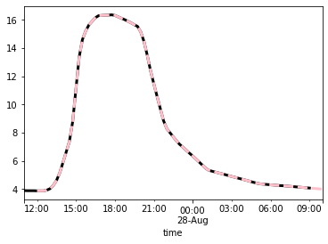

```python
i = 800
old_events_series[i].streamflow.plot(color="k",linewidth=3)
new_events_series[i-2].streamflow.plot(color="pink",linestyle="--",linewidth=3)
```

Here the old routine detects this as one event, but the new one detects it as two different ones.

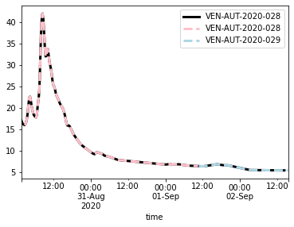

```python
i = 888
old_events_series[i].streamflow.plot(color="k",label=old_events_list.index[i],linewidth=3)
new_events_series[i-2].streamflow.plot(color="pink",linestyle="--",label=new_events_list.index[i-2],linewidth=3)
new_events_series[i-1].streamflow.plot(color="lightblue",linestyle="--",label=new_events_list.index[i-1],linewidth=3)
plt.legend()
```

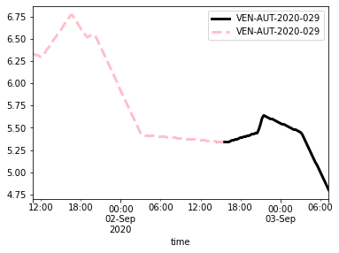

```python
i = 889
old_events_series[i].streamflow.plot(color="k",label=old_events_list.index[i],linewidth=3)
new_events_series[i-2].streamflow.plot(color="pink",linestyle="--",label=new_events_list.index[i-2],linewidth=3)
plt.legend()
```

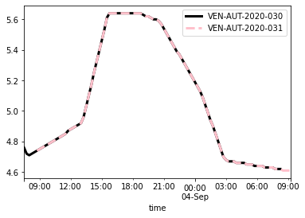

```python
i = 890
old_events_series[i].streamflow.plot(color="k",linewidth=3,label=old_events_list.index[i])
new_events_series[i-1].streamflow.plot(color="pink",linestyle="--",linewidth=3,label=new_events_list.index[i-1])
plt.legend()
```

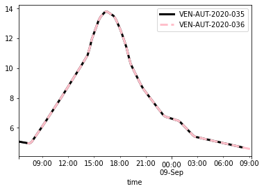

```python
i = 895
old_events_series[i].streamflow.plot(color="k",linewidth=3,label=old_events_list.index[i])
new_events_series[i-1].streamflow.plot(color="pink",linestyle="--",linewidth=3,label=new_events_list.index[i-1])
plt.legend()
```

Then there is again a shift. This time it's an event that is not detected by the new routine at all. Note again how the start of the old event (black) is not at the local minima.

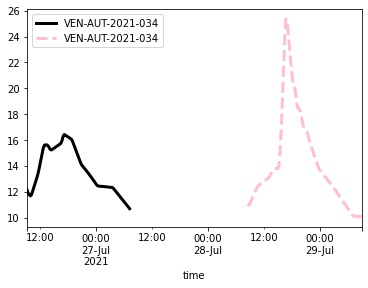

```python
i = 940
old_events_series[i].streamflow.plot(color="k",linewidth=3,label=old_events_list.index[i])
new_events_series[i-1].streamflow.plot(color="pink",linestyle="--",linewidth=3,label=new_events_list.index[i-1])
plt.legend()
```

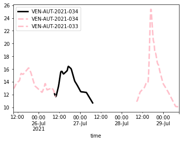

```python
i = 940
old_events_series[i].streamflow.plot(color="k",linewidth=3,label=old_events_list.index[i])
new_events_series[i-1].streamflow.plot(color="pink",linestyle="--",linewidth=3,label=new_events_list.index[i-1])
new_events_series[i-2].streamflow.plot(color="pink",linestyle="--",linewidth=3,label=new_events_list.index[i-2])
plt.legend()
```

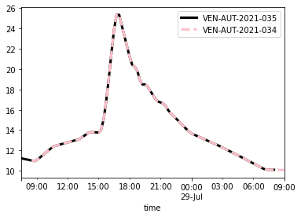

```python
i = 941
old_events_series[i].streamflow.plot(color="k",linewidth=3,label=old_events_list.index[i])
new_events_series[i-2].streamflow.plot(color="pink",linestyle="--",linewidth=3,label=new_events_list.index[i-2])
plt.legend()
```

So at the final event the old routine has in total detected two more event than the new one.

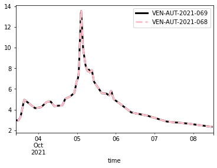

```python
# last event
i = 975
old_events_series[i].streamflow.plot(color="k",linewidth=3,label=old_events_list.index[i])
new_events_series[i-2].streamflow.plot(color="pink",linestyle="--",linewidth=3,label=new_events_list.index[i-2])
plt.legend()
```

```python
print(len(new_events_list),"new events detected.")
print(len(old_events_list),"old events detected.")
```

```
974 new events detected.
976 old events detected.
```